# Tugas Analisis Regresi Sederhana

Shabrina Nur Izzati | M0401241011

2026-02-21

# Pemanggilan Library Yang Diperlukan

```r
library(readxl)
library(dplyr)
library(ggplot2)
```

# Data Steps

```r
rawdata <- read_excel("C:\\Users\\User\\github_project\\Analisis-Regresi\\Dataset\\AnregIKPraw.xlsx")

head(rawdata, 10)
```

```
## # A tibble: 10 × 15
##    `Nama Kabupaten` `IKP (Indeks Ketahanan Pangan)` Persentase Penduduk Miskin…¹
##    <chr>                                      <dbl>                        <dbl>
##  1 Simeulue                                    77.5                         17.7
##  2 Aceh Singkil                                46.1                         19.1
##  3 Aceh Selatan                                73.8                         12.0
##  4 Aceh Tenggara                               76.9                         12.0
##  5 Aceh Timur                                  77.2                         13.3
##  6 Aceh Tengah                                 69.1                         14.3
##  7 Aceh Barat                                  78.3                         17.6
##  8 Aceh Besar                                  84.7                         13.2
##  9 Pidie                                       76.7                         18.6
## 10 Bireuen                                     80.8                         12.1
## # ℹ abbreviated name:
## #   ¹`Persentase Penduduk Miskin (P0) Menurut Kabupaten/Kota (Persen)`
## # ℹ 12 more variables:
## #   `Rata-rata Konsumsi Perkapita Seminggu Nasi Putih` <dbl>,
## #   `Rata-rata Konsumsi Perkapita Seminggu Ayam/Daging Matang` <chr>,
## #   `Rata-rata Konsumsi Perkapita Seminggu Ikan Matang` <chr>,
## #   `Rata-rata Konsumsi Perkapita Seminggu Air Kemasan` <chr>, …
```

```r
summary(rawdata)
```

```
##  Nama Kabupaten     IKP (Indeks Ketahanan Pangan)
##  Length:514         Min.   :14.14
##  Class :character   1st Qu.:71.28
##  Mode  :character   Median :79.03
##                     Mean   :75.11
##                     3rd Qu.:84.64
##                     Max.   :96.37
##
##  Persentase Penduduk Miskin (P0) Menurut Kabupaten/Kota (Persen)
##  Min.   : 2.23
##  1st Qu.: 6.36
##  Median : 9.31
##  Mean   :11.11
##  3rd Qu.:13.69
##  Max.   :41.42
##  NA's   :3
##  Rata-rata Konsumsi Perkapita Seminggu Nasi Putih
##  Min.   :0.0010
##  1st Qu.:0.0595
##  Median :0.1280
##  Mean   :0.1996
##  3rd Qu.:0.2885
##  Max.   :1.7770
##  NA's   :11
##  Rata-rata Konsumsi Perkapita Seminggu Ayam/Daging Matang
##  Length:514
##  Class :character
##  Mode  :character
##
##
##
##
##  Rata-rata Konsumsi Perkapita Seminggu Ikan Matang
##  Length:514
##  Class :character
##  Mode  :character
##
##
##
##
```

[output cut: 57 more lines]

```
##  Min.   :0.187
##  1st Qu.:1.461
##  Median :1.672
##  Mean   :1.679
##  3rd Qu.:1.889
##  Max.   :2.914
##  NA's   :6
##  Indeks Kedalaman Kemiskinan (P1) Menurut Kabupaten/Kota
##  Min.   : 0.130
##  1st Qu.: 0.790
##  Median : 1.230
##  Mean   : 1.742
##  3rd Qu.: 2.085
##  Max.   :12.810
##  NA's   :3
```

## Matriks Korelasi

[figure not shown]

```r
library(corrplot)
data_num <- rawdata %>%
  select(where(is.numeric))

cor_mat <- cor(data_num, use = "pairwise.complete.obs")

corrplot(cor_mat,
         method = "color",
         type = "upper",
         tl.col = "black",
         tl.cex = 0.1,
         addCoef.col = "black",
         diag = FALSE)
```

## Pemilihan Variabel Y dan X

```r
y <- rawdata$`IKP (Indeks Ketahanan Pangan)`
x <- rawdata$`Persentase Penduduk Miskin (P0) Menurut Kabupaten/Kota (Persen)`
dataregs <- data.frame(y,x)
head(dataregs, 10)
```

```
##        y     x
## 1  77.54 17.69
## 2  46.10 19.06
## 3  73.84 12.02
## 4  76.87 11.99
## 5  77.19 13.26
## 6  69.08 14.27
## 7  78.27 17.60
## 8  84.72 13.21
## 9  76.69 18.59
## 10 80.83 12.10
```

## Ambil 30 Data

```r
set.seed(209)
dregscl <- dataregs %>% na.omit() %>% sample_n(30)
dregscl
```

```
##        y     x
## 1  90.52  3.03
## 2  75.32  6.87
## 3  78.26 13.88
## 4  25.07 28.95
## 5  70.45 21.37
## 6  75.01  8.40
## 7  87.29 11.43
## 8  76.02 18.66
## 9  86.59  8.26
## 10 88.89  3.74
## 11 80.49  7.40
## 12 83.86  8.75
## 13 76.88 10.79
## 14 57.34  5.21
```

[output cut: 16 more lines]

# Eksplorasi Data

## Ringkasan Data

```r
summary(dregscl)
```

```
##        y               x
##  Min.   :22.27   Min.   : 2.920
##  1st Qu.:75.42   1st Qu.: 6.207
##  Median :80.86   Median : 8.525
##  Mean   :75.44   Mean   :11.387
##  3rd Qu.:85.62   3rd Qu.:13.838
##  Max.   :91.63   Max.   :37.070
```

## Scatter Plot

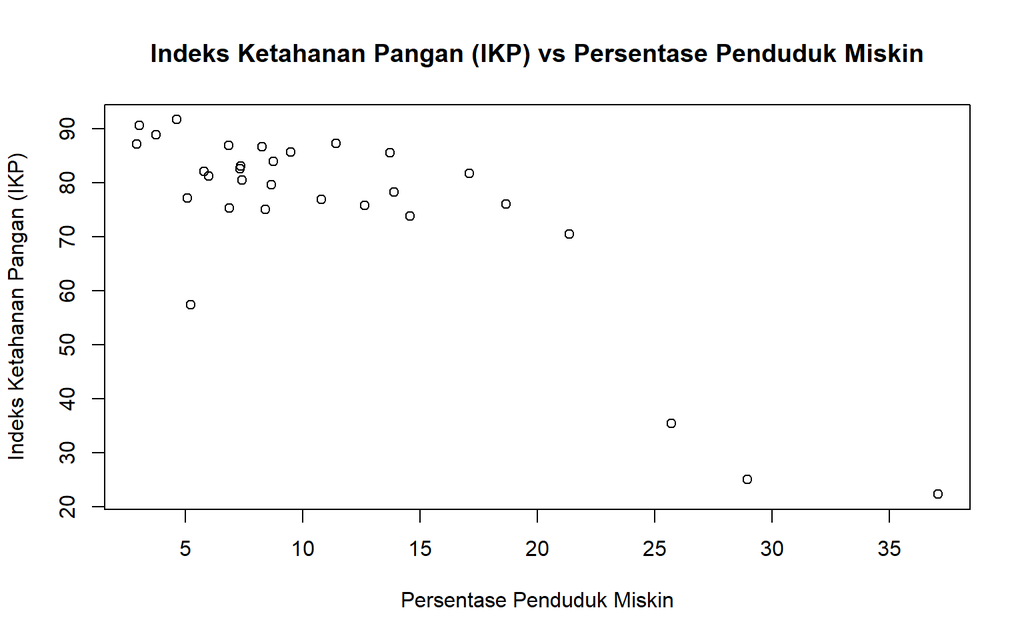

```r
plot(dregscl$x, dregscl$y,
     main = "Indeks Ketahanan Pangan (IKP) vs Persentase Penduduk Miskin",
     xlab = "Persentase Penduduk Miskin",
     ylab = "Indeks Ketahanan Pangan (IKP)")
```

## Boxplot

### Boxplot Indeks Ketahanan Pangan

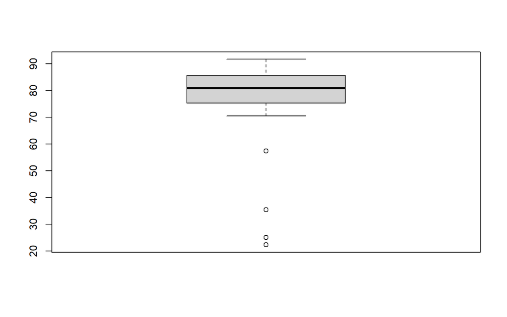

```r
boxplot(dregscl$y)
```

### Boxplot Persentase Penduduk Miskin

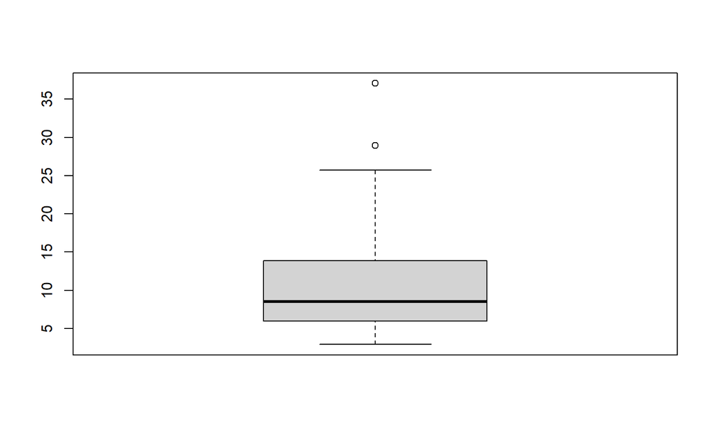

```r
boxplot(dregscl$x)
```

# Pembentukan Model

## Otomatis

### Model

```r
model <- lm(y~x, dregscl)
summary(model)
```

```
##
## Call:
## lm(formula = y ~ x, data = dregscl)
##
## Residuals:
##      Min       1Q   Median       3Q      Max
## -29.2917  -3.9004   0.1171   5.1478  16.6345
##
## Coefficients:
##             Estimate Std. Error t value Pr(>|t|)
## (Intercept)  96.0693     3.2301  29.742  < 2e-16 ***
## x            -1.8114     0.2327  -7.786 1.76e-08 ***
## ---
## Signif. codes:  0 '***' 0.001 '**' 0.01 '*' 0.05 '.' 0.1 ' ' 1
##
## Residual standard error: 10.12 on 28 degrees of freedom
## Multiple R-squared:  0.684,  Adjusted R-squared:  0.6728
## F-statistic: 60.62 on 1 and 28 DF,  p-value: 1.759e-08
```

Berdasarkan perhitungan, didapat dugaan persamaan regresi linear sebagai berikut:

$$E[\hat{Y}] = \hat{Y} = 96.0693 -
1.8114X$$

Dugaan persamaan tersebut dapat pula disebut sebagai nilai harapan dari peubah respons **Y (Indeks Ketahanan Pangan)** pada setiap nilai peubah prediktor **X (Persentase Penduduk Miskin)**.

- **Nilai $\beta_0$ (Intercept) = 96.0693** Merupakan taksiran Indeks Ketahanan Pangan ketika $X = 0\%$. Secara praktis kurang relevan karena $X = 0\%$ tidak realistis, namun tetap penting dalam model matematis. kenaikan $1\%$ Persentase Penduduk Miskin akan menurunkan Indeks Ketahanan Pangan sebesar $1.8114$, dengan asumsi faktor lain konstan.
- **Nilai $\beta_1$ (Slope) = -1.8114** Mengindikasikan bahwa setiap kenaikan 1 satuan Persentase Penduduk Miskin akan menurunkan Indeks Ketahanan Pangan sebesar 1.8114, dengan asumsi faktor lain konstan.

### Hipotesis

Hipotesis yang digunakan untuk menguji parameter regresi adalah:

$$H_0 : \beta_1 = 0$$
$$H_1 : \beta_1 \neq 0$$

- **$H_0$** : Tidak ada pengaruh Persentase Penduduk Miskin terhadap Indeks Ketahanan Pangan.
- **$H_1$** : Ada pengaruh Persentase Penduduk Miskin terhadap Indeks Ketahanan Pangan.

Dengan taraf nyata $\alpha = 0.05$.

### ANOVA

```r
anova(model)
```

```
## Analysis of Variance Table
##
## Response: y
##           Df Sum Sq Mean Sq F value    Pr(>F)
## x          1 6210.9  6210.9  60.618 1.759e-08 ***
## Residuals 28 2868.8   102.5
## ---
## Signif. codes:  0 '***' 0.001 '**' 0.01 '*' 0.05 '.' 0.1 ' ' 1
```

Diperoleh bahwa nilai p-value < 0,05 atau F hitung > F tabel, sehingga H0 ditolak.

Oleh karena itu, model regresi yang dibentuk signifikan secara statistik pada taraf signifikansi 5%. Yang berarti ariabel persentase penduduk miskin secara signifikan berpengaruh terhadap Indeks Ketahanan Pangan.

Dengan koefisien regresi < 0 yang berarti persentase penduduk miskin berkaitan dengan penurunan Indeks Ketahanan Pangan

### Koefisien Determinansi

```r
summary(model)$r.squared
```

```
## [1] 0.6840388
```

Sekitar 68,4% variasi Indeks Ketahanan Pangan dapat dijelaskan oleh variabel persentase penduduk miskin melalui model regresi yang dibentuk. Sedangkan sisanya sebesar 31,6% dipengaruhi oleh faktor-faktor lain di luar model yang tidak dimasukkan dalam analisis.

## Manual

### Menentukan b0 dan b1

$$\hat{\beta}_1 = \frac{\sum_{i=1}^{n}(X_i - \bar{X})(Y_i - \bar{Y})}
{\sum_{i=1}^{n}(X_i - \bar{X})^2}$$

$$\hat{\beta}_0 = \bar{Y} - \hat{\beta}_1 \bar{X}$$

```r
x <- dregscl$x
y <- dregscl$y
x_bar <- mean(x)
y_bar <- mean(y)
Sxx <- sum((x - x_bar)^2)
Sxy <- sum((x - x_bar)*(y - y_bar))
Syy <- sum((y - y_bar)^2)
b1 <- Sxy/Sxx
b0 <- y_bar - b1*x_bar
```

```r
cat("b1 =", b1)
```

```
## b1 = -1.811443
```

```r
cat("b0 =", b0)
```

```
## b0 = 96.06929
```

### Menentukan SSE, SSR, SST

```r
dregscl$x_square <- x^2
dregscl$xy <- x*y
dregscl$y_hat <- b0 + b1*x
dregscl$residual <- y - dregscl$y_hat
dregscl$residual_square <- dregscl$residual^2
head(dregscl)
```

```
##       y     x x_square        xy    y_hat     residual residual_square
## 1 90.52  3.03   9.1809  274.2756 90.58062  -0.06062196    3.675021e-03
## 2 75.32  6.87  47.1969  517.4484 83.62468  -8.30468239    6.896775e+01
## 3 78.26 13.88 192.6544 1086.2488 70.92647   7.33353020    5.378067e+01
## 4 25.07 28.95 838.1025  725.7765 43.62803 -18.55802988    3.444005e+02
## 5 70.45 21.37 456.6769 1505.5165 57.35876  13.09123524    1.713804e+02
## 6 75.01  8.40  70.5600  630.0840 80.85318  -5.84317522    3.414270e+01
```

```r
SSR <- sum((dregscl$y_hat - y_bar)^2)
SSE <- sum(dregscl$residual_square)
SST_1 <- Syy  #cara 1
SST_2 <- SSR + SSE #cara 2
SST <- SST_1
```

```r
cat("SST =", SST)
```

```
## SST = 9079.69
```

```r
cat("SSR =", SSR)
```

```
## SSR = 6210.861
```

```r
cat("SSE =", SSE)
```

```
## SSE = 2868.83
```

### Menentukan F-Hitung

```r
n <- 30
df_reg <- 1
df_err <- n - 2
df_tot <- n - 1
MSR <- SSR/df_reg
MSE <- SSE/df_err
F_hit <- MSR/MSE
cat("F_hit =", F_hit)
```

```
## F_hit = 60.61848
```

### Menentukan R-Square

```r
RSquare <- SSR/SST
RSquare
```

```
## [1] 0.6840388
```

### Uji-t Koefisien Regresi

#### Uji-t b0

```r
uji <- 0
SE_b0 <- sqrt(MSE * (1/n + (x_bar^2)/Sxx))
t_hit_b0 <- (b0 - uji) / SE_b0
t_tab_b0 <- abs(qt(0.025, df = n-2))
cat("t_hit =", t_hit_b0)
```

```
## t_hit = 29.74173
```

```r
cat("t_tab =", t_tab_b0)
```

```
## t_tab = 2.048407
```

Karena t hitung > t tabel, berarti H0 ditolak untuk b0. Artinya, intercept (b0) secara statistik signifikan berbeda dari nol. Dengan kata lain, ketika persentase penduduk miskin = 0%, maka nilai rata-rata Indeks Ketahanan Pangan secara statistik tidak sama dengan nol. Namun, interpretasi b0 seringkali kurang bermakna karena kondisi X = 0% tidak realistis dalam konteks data.

#### Uji-t b1

```r
uji <- 0
SE_b1 <- sqrt(MSE/Sxx)
t_hit_b1 <- (b1 - uji)/SE_b1
t_tab_b1 <- abs(qt(0.025, df = n-2))
cat("t_hit =", t_hit_b1)
```

```
## t_hit = -7.785787
```

```r
cat("t_tab =", t_tab_b1)
```

```
## t_tab = 2.048407
```

### Selang Kepercayaan Parameter

```r
t_tabel <- qt(0.975, df_err)
t_tabel
```

```
## [1] 2.048407
```

#### Selang Kepercayaan b0

```r
CI_b0_lower <- b0 - t_tabel*SE_b0
CI_b0_upper <- b0 + t_tabel*SE_b0
cat("Selang kepercayaan b0: [", CI_b0_lower, ", ", CI_b0_upper, "]")
```

```
## Selang kepercayaan b0: [ 89.4527 ,  102.6859 ]
```

Kita 95% yakin bahwa nilai sebenarnya dari b0 berada dalam interval [ 89.4527 , 102.6859 ].

#### Selang Kepercayaan b1

```r
CI_b1_lower <- b1 - t_tabel*SE_b1
CI_b1_upper <- b1 + t_tabel*SE_b1
cat("Selang kepercayaan b1: [", CI_b1_lower, ", ", CI_b1_upper, "]")
```

```
## Selang kepercayaan b1: [ -2.288025 ,  -1.33486 ]
```

Kita 95% yakin bahwa nilai sebenarnya dari b1 berada dalam interval [ -2.288025 , -1.33486 ].

#### Selang Kepercayaan Nilai Rataan/Harapan

##### Manual

```r
x0 <- mean(x)
SE_mean <- sqrt(MSE*(1/n + (x0 - x_bar)^2/Sxx))
y0_hat <- b0 + b1*x0
CI_mean_lower <- y0_hat - t_tabel*SE_mean
CI_mean_upper <- y0_hat + t_tabel*SE_mean

cat("Selang Kepercayaan Nilai Rataan: [", CI_mean_lower, ", ", CI_mean_upper, "]")
```

```
## Selang Kepercayaan Nilai Rataan: [ 71.65745 ,  79.22855 ]
```

##### Otomatis

```r
dugaan_amatan <- data.frame(x=x0)
predict(model, dugaan_amatan, interval = "confidence")
```

```
##      fit      lwr      upr
## 1 75.443 71.65745 79.22855
```

Kita 95% yakin bahwa nilai sebenarnya dari Nilai Rataan/Harapan berada dalam interval [ 71.65745 , 79.22855 ]

#### Selang Kepercayaan Individu Amatan (Prediksi)

##### Manual

```r
SE_pred <- sqrt(MSE*(1 + 1/n + (x0 - x_bar)^2/Sxx))
PI_lower <- y0_hat - t_tabel*SE_pred
PI_upper <- y0_hat + t_tabel*SE_pred

cat("Selang Kepercayaan Individu: [", PI_lower, ", ", PI_upper, "]")
```

```
## Selang Kepercayaan Individu: [ 54.36595 ,  96.52005 ]
```

##### Otomatis

```r
predict(model, dugaan_amatan, interval="prediction")
```

```
##      fit      lwr      upr
## 1 75.443 54.36595 96.52005
```

Kita 95% yakin bahwa nilai sebenarnya dari Individu Amatan berada dalam interval [ 54.36595 , 96.52005 ]

# Visualisasi

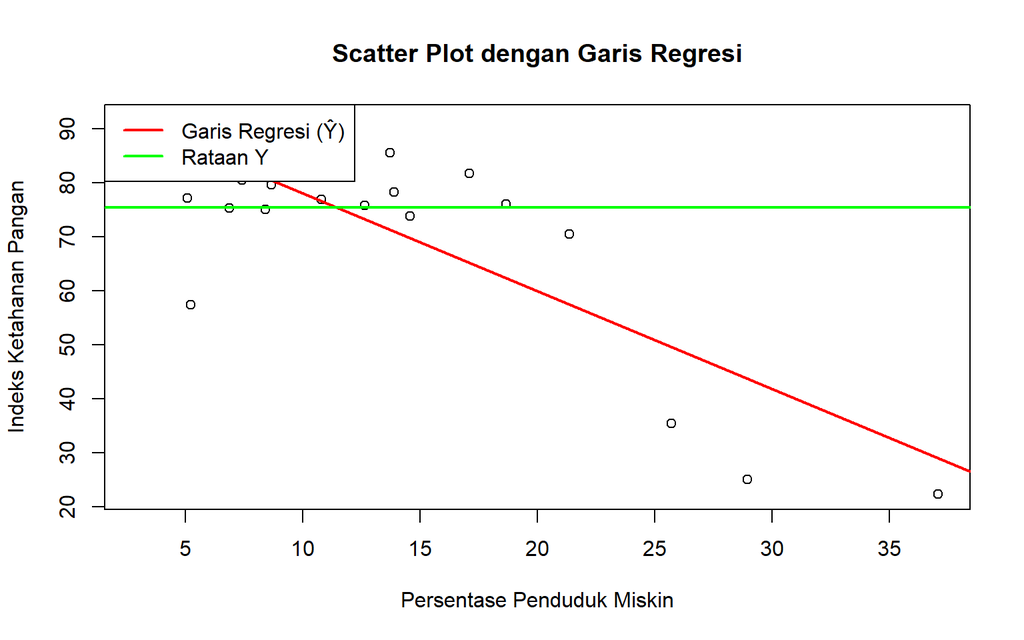

```r
plot(x, y,
main="Scatter Plot dengan Garis Regresi",
xlab="Persentase Penduduk Miskin",
ylab="Indeks Ketahanan Pangan")
abline(model, col="red", lwd=2)
abline(h=mean(y), col="green", lwd=2)
legend("topleft",
legend=c("Garis Regresi (Ŷ)", "Rataan Y"),
col=c("red", "green"),
lwd=2)
```

Grafik menunjukkan hubungan linear yang negatif antara Persentase Penduduk Miskin dan Indeks Ketahanan Pangan. Semakin tinggi Persentase Penduduk Miskin, semakin rendah Indeks Ketahanan Pangan.